# R Mini Project 4: R Script Covering Outliers and Graphs

Thinh Le

2024-11-08

# Background

As the data scientist, you have been asked to create a report on food-borne illness outbreaks related to Norovirus and Escherichia coli (E. coli). You are given the dataset in Excel format, NORS_20241106.xlsx (Available on Blackboard),

This project uses data from the National Outbreak Reporting System (NORS). NORS is a web-based platform designed to support reporting to the US Centers for Disease Control and Prevention by local, state, and territorial health departments in the United States of all waterborne disease outbreaks and enteric disease outbreaks transmitted by food, contact with environmental sources, infected persons or animals, or unknown modes of transmission. A dashboard is available from the CDC at https://www.cdc.gov/ncezid/dfwed/beam-dashboard.html and the data was downloaded from https://data.cdc.gov/Foodborne-Waterborne-and-Related-Diseases/NORS/5xkq-dg7x/about_data on November 6, 2024.

If you do not like food-borne diseases (come on! No one wants to get sick from a delicious cookie!), you can pretend the data are on anything. This application applies to any situation where you are asked to explore a dataset with quantitative measurements on three different types of items. In this specific case, it is enteric illnesses.

# Loads all necessary libraries and init global variables

```r
# Load the libraries
library(dplyr)     # Work with data frames
library(lubridate) # Work with date & time
library(stringr)   # Work with strings
library(ggplot2)   # Work with graphs
library(tidyr)     # Work with data
library(readxl)    # Read excel files

# Create colors
z_300 <- "#d4d4d8"
r_900 <- "#450a0a"
```

# Reads the data

```r
# Read the data, the data file must be in the same folder with the source file
df <- read_excel('NORS_20241106.xlsx', sheet = 'NORS_20241106')
```

# Describes the data

## Views a glimpse of data

```r
# Use glimpse() to view the structure of the data
glimpse(df)
```

```
Rows: 62,415
Columns: 19
$ Year                           <dbl> 2009, 2009, 2009, 2009, 2009, 2009, 2009, 2009, 2010, 2010, 2010, 2010, 2011, 2010, 2010, 2011, 2011,…
$ Month                          <dbl> 1, 1, 10, 1, 12, 4, 6, 8, 8, 4, 4, 12, 1, 12, 12, 1, 3, 12, 1, 3, 8, 5, 5, 6, 3, 7, 11, 8, 12, 12, 2,…
$ State                          <chr> "Alaska", "Iowa", "Kansas", "North Dakota", "Ohio", "West Virginia", "Nevada", "Michigan", "Oregon", …
$ `Primary Mode`                 <chr> "Person-to-person", "Person-to-person", "Food", "Person-to-person", "Food", "Person-to-person", "Food…
$ Etiology                       <chr> "Norovirus unknown", "Norovirus unknown", "Norovirus unknown", NA, "Clostridium perfringens", NA, "No…
$ `Serotype or Genotype`         <chr> NA, NA, NA, NA, NA, NA, NA, NA, "O157:H7", NA, NA, "unknown", NA, NA, NA, NA, NA, NA, NA, "unknown", …
$ `Etiology Status`              <chr> "Confirmed", "Confirmed", "Suspected", NA, "Confirmed", NA, "Confirmed", NA, "Confirmed", "Confirmed"…
$ Setting                        <chr> NA, "Restaurant", "Restaurant: Sit-down dining", "Long-term care/nursing home/assisted living facilit…
$ Illnesses                      <dbl> 6, 56, 4, 77, 9, 59, 44, 33, 3, 13, 19, 36, 40, 68, 39, 35, 69, 5, 46, 9, 26, 24, 55, 2, 23, 16, 6, 1…
$ Hospitalizations               <dbl> 0, 2, 0, 0, 0, 2, 0, 0, 2, 0, 0, 2, 0, 0, 1, 0, 0, 0, 0, 0, 0, 0, 1, 1, 0, 0, 0, 0, 0, 0, 0, 0, 2, 0,…
$ `Info On Hospitalizations`     <dbl> 6, 56, 4, 57, 9, 59, 44, 33, 3, 0, 19, 36, 40, 68, 39, 35, 69, 5, 0, 9, 26, 0, 55, 2, 23, 0, 6, 13, 5…
$ Deaths                         <dbl> 0, 0, 0, 0, 0, 0, 0, 0, 0, 0, 0, 0, 0, 0, 1, 0, 0, 0, 0, 0, 0, 0, 0, 0, 0, 0, 0, 0, 0, 0, 0, 0, 0, 0,…
$ `Info On Deaths`               <dbl> 6, 56, 4, 57, 9, 59, 44, 33, 3, 13, 19, 36, 40, 68, 39, 35, 69, 5, 46, 9, 26, 0, 55, 2, 23, 0, 6, 13,…
$ `Food Vehicle`                 <chr> NA, NA, NA, NA, "roast beef", NA, NA, "pork", NA, "beans, baked;pork, bbq", "ice cream cake", NA, NA,…
$ `Food Contaminated Ingredient` <chr> NA, NA, NA, NA, NA, NA, NA, "pork", NA, NA, NA, NA, NA, NA, NA, NA, NA, NA, NA, NA, NA, NA, NA, NA, N…
$ `IFSAC Category`               <chr> NA, NA, NA, NA, "Beef", NA, NA, "Pork", NA, "Multiple", "Multiple", NA, NA, NA, NA, NA, NA, NA, NA, N…
$ `Water Exposure`               <chr> NA, NA, NA, NA, NA, NA, NA, NA, NA, NA, NA, NA, NA, NA, NA, NA, NA, NA, NA, NA, NA, NA, NA, NA, NA, N…
$ `Water Type`                   <chr> NA, NA, NA, NA, NA, NA, NA, NA, NA, NA, NA, NA, NA, NA, NA, NA, NA, NA, NA, NA, NA, NA, NA, NA, NA, N…
$ `Animal Type`                  <chr> NA, NA, NA, NA, NA, NA, NA, NA, NA, NA, NA, NA, NA, NA, NA, NA, NA, NA, NA, NA, NA, NA, NA, NA, NA, N…
```

## Views data summary

```r
# View data summary
summary(df)
```

```
      Year          Month           State           Primary Mode         Etiology         Serotype or Genotype Etiology Status
 Min.   :1971   Min.   : 1.000   Length:62415       Length:62415       Length:62415       Length:62415         Length:62415
 1st Qu.:2009   1st Qu.: 2.000   Class :character   Class :character   Class :character   Class :character     Class :character
 Median :2013   Median : 5.000   Mode  :character   Mode  :character   Mode  :character   Mode  :character     Mode  :character
 Mean   :2012   Mean   : 5.706
 3rd Qu.:2017   3rd Qu.: 9.000
 Max.   :2022   Max.   :12.000

   Setting            Illnesses      Hospitalizations  Info On Hospitalizations     Deaths       Info On Deaths    Food Vehicle
 Length:62415       Min.   :     2   Min.   :  0.000   Min.   :   0.00          Min.   : 0.000   Min.   :   0.00   Length:62415
 Class :character   1st Qu.:     5   1st Qu.:  0.000   1st Qu.:   3.00          1st Qu.: 0.000   1st Qu.:   4.00   Class :character
 Mode  :character   Median :    14   Median :  0.000   Median :  10.00          Median : 0.000   Median :  11.00   Mode  :character
                    Mean   :    34   Mean   :  0.821   Mean   :  19.89          Mean   : 0.043   Mean   :  20.75
                    3rd Qu.:    30   3rd Qu.:  1.000   3rd Qu.:  25.00          3rd Qu.: 0.000   3rd Qu.:  26.00
                    Max.   :403000   Max.   :308.000   Max.   :2500.00          Max.   :50.000   Max.   :2500.00
                                     NA's   :8215      NA's   :8114             NA's   :7502     NA's   :8124
 Food Contaminated Ingredient IFSAC Category     Water Exposure      Water Type        Animal Type
 Length:62415                 Length:62415       Length:62415       Length:62415       Length:62415
 Class :character             Class :character   Class :character   Class :character   Class :character
 Mode  :character             Mode  :character   Mode  :character   Mode  :character   Mode  :character
```

## Views data dimension

```r
# View data dimension
dim(df)
```

```
[1] 62415    19
```

There are 62415 rows and 19 columns.

## Views the column names

```r
# View the column names
colnames(df)
```

```
 [1] "Year"                         "Month"                        "State"                        "Primary Mode"
 [5] "Etiology"                     "Serotype or Genotype"         "Etiology Status"              "Setting"
 [9] "Illnesses"                    "Hospitalizations"             "Info On Hospitalizations"     "Deaths"
[13] "Info On Deaths"               "Food Vehicle"                 "Food Contaminated Ingredient" "IFSAC Category"
[17] "Water Exposure"               "Water Type"                   "Animal Type"
```

Remove white spaces in column names by renaming them:

```r
df <- df %>%
  rename(
    "Primary_Mode"                 = `Primary Mode`,
    "Serotype_Or_Genotype"         = `Serotype or Genotype`,
    "Etiology_Status"              = `Etiology Status`,
    "Info_On_Hospitalizations"     = `Info On Hospitalizations`,
    "Info_On_Deaths"               = `Info On Deaths`,
    "Food_Vehicle"                 = `Food Vehicle`,
    "Food_Contaminated_Ingredient" = `Food Contaminated Ingredient`,
    "IFSAC_Category"               = `IFSAC Category`,
    "Water_Exposure"               = `Water Exposure`,
    "Water_Type"                   = `Water Type`,
    "Animal_Type"                  = `Animal Type`
  )
```

## View the top 10 rows

```r
# View the first 10 rows
head(df, n = 10)
```

| Year | Month | State | Primary_Mode | Etiology | Serotype_Or_Genotype | Etiology_Status | Setting | Illnesses | Hospitalizations | Info_On_Hospitalizations | Deaths | Info_On_Deaths | Food_Vehicle | Food_Contaminated_Ingredient | IFSAC_Category | Water_Exposure | Water_Type | Animal_Type |
| --- | --- | --- | --- | --- | --- | --- | --- | --- | --- | --- | --- | --- | --- | --- | --- | --- | --- | --- |
| 2009 | 1 | Alaska | Person-to-person | Norovirus unknown | NA | Confirmed | NA | 6 | 0 | 6 | 0 | 6 | NA | NA | NA | NA | NA | NA |
| 2009 | 1 | Iowa | Person-to-person | Norovirus unknown | NA | Confirmed | Restaurant | 56 | 2 | 56 | 0 | 56 | NA | NA | NA | NA | NA | NA |
| 2009 | 10 | Kansas | Food | Norovirus unknown | NA | Suspected | Restaurant: Sit-down dining | 4 | 0 | 4 | 0 | 4 | NA | NA | NA | NA | NA | NA |
| 2009 | 1 | North Dakota | Person-to-person | NA | NA | NA | Long-term care/nursing home/assisted living facility | 77 | 0 | 57 | 0 | 57 | NA | NA | NA | NA | NA | NA |
| 2009 | 12 | Ohio | Food | Clostridium perfringens | NA | Confirmed | Caterer | 9 | 0 | 9 | 0 | 9 | roast beef | NA | Beef | NA | NA | NA |
| 2009 | 4 | West Virginia | Person-to-person | NA | NA | NA | Long-term care/nursing home/assisted living facility | 59 | 2 | 59 | 0 | 59 | NA | NA | NA | NA | NA | NA |
| 2009 | 6 | Nevada | Food | Norovirus unknown | NA | Confirmed | Banquet Facility (food prepared and served on-site) | 44 | 0 | 44 | 0 | 44 | NA | NA | NA | NA | NA | NA |
| 2009 | 8 | Michigan | Food | NA | NA | NA | Restaurant: Other;Caterer | 33 | 0 | 33 | 0 | 33 | pork | pork | Pork | NA | NA | NA |
| 2010 | 8 | Oregon | Indeterminate/unknown | Escherichia coli, Shiga toxin-producing | O157:H7 | Confirmed | Other | 3 | 2 | 3 | 0 | 3 | NA | NA | NA | NA | NA | NA |
| 2010 | 4 | Florida | Food | Norovirus Genogroup II | NA | Confirmed | Private home/residence | 13 | 0 | 0 | 0 | 13 | beans, baked;pork, bbq | NA | Multiple | NA | NA | NA |

## View the last 10 rows

```r
# View the last 10 rows
tail(df, n = 10)
```

| Year | Month | State | Primary_Mode | Etiology | Serotype_Or_Genotype | Etiology_Status | Setting | Illnesses | Hospitalizations | Info_On_Hospitalizations | Deaths | Info_On_Deaths | Food_Vehicle | Food_Contaminated_Ingredient | IFSAC_Category | Water_Exposure | Water_Type | Animal_Type |
| --- | --- | --- | --- | --- | --- | --- | --- | --- | --- | --- | --- | --- | --- | --- | --- | --- | --- | --- |
| 2020 | 7 | Wisconsin | Water | Legionella pneumophila | serogroup 1 | Confirmed | Private home/residence | 3 | 1 | 1 | 0 | 1 | NA | NA | NA | Recreational water -- treated | Hot Tub/Spa/Whirlpool | NA |
| 2020 | 1 | Rhode Island | Person-to-person | Norovirus Genogroup II | unknown unknown | Confirmed | Long-term care/nursing home/assisted living facility | 57 | 0 | 57 | 0 | 57 | NA | NA | NA | NA | NA | NA |
| 2022 | 2 | Wisconsin | Person-to-person | Norovirus unknown | NA | Confirmed | Long-term care/nursing home/assisted living facility | 17 | 1 | 17 | 0 | 17 | NA | NA | NA | NA | NA | NA |
| 2019 | 4 | Washington | Person-to-person | NA | NA | NA | Long-term care/nursing home/assisted living facility | 6 | 0 | 0 | 0 | 0 | NA | NA | NA | NA | NA | NA |
| 2022 | 2 | Tennessee | Person-to-person | Norovirus Genogroup II | unknown unknown | Confirmed | Long-term care/nursing home/assisted living facility | 23 | 2 | 23 | 0 | 23 | NA | NA | NA | NA | NA | NA |
| 2019 | 9 | California | Food | Norovirus unknown | NA | Suspected | Restaurant: “Fast-food”\u009d (drive up service or pay at counter) | 5 | 0 | 5 | 0 | 5 | sushi | NA | Multiple | NA | NA | NA |
| 1982 | 5 | Indiana | Water | Unknown | NA | Suspected | Camp/cabin | 400 | NA | NA | 0 | NA | NA | NA | NA | Drinking water | Community | NA |
| 2020 | 2 | Rhode Island | Person-to-person | Norovirus unknown | NA | Suspected | School/college/university | 12 | 0 | 12 | 0 | 12 | NA | NA | NA | NA | NA | NA |
| 2020 | 1 | Colorado | Person-to-person | NA | NA | NA | School/college/university | 6 | 0 | 0 | 0 | 6 | NA | NA | NA | NA | NA | NA |
| 2020 | 1 | Illinois | Food | Norovirus Genogroup II | unknown unknown | Suspected | Long-term care/nursing home/assisted living facility | 30 | 0 | 0 | 0 | 0 | NA | NA | NA | NA | NA | NA |

# Explores and cleans the data

## Checks for NAs or blanks.

```r
# Count the number of rows in the data frame that contain NA values
paste0(nrow(df[!complete.cases(df), ]), "/", nrow(df))
```

```
[1] "62415/62415"
```

The result shows that all rows have at least one column containing NA.

## Do you need to take appropriate action to address the missing values? Explain why you believe the NAs should be there

Based on the FAQ on the website, here are some reasons that NAs exist in the dataset:

> - NORS collects information only on disease outbreaks of enteric illness, except for some non-enteric illness outbreaks spread through contaminated food or water.
> - NORS does not collect information on disease outbreaks that result from an exposure in a non-U.S. location.
> - Health departments might not report all foodborne, waterborne, or enteric disease outbreaks to NORS.
>   - Some outbreaks are never identified.
>   - Some outbreaks are not investigated.
>   - Some outbreak investigations cannot be completed.
> - The NORS View contains only information reported to NORS that CDC has reviewed.

Check for NAs or blanks, or both NAs and blanks in each column:

```r
# For each column
for (column_name in colnames(df))
{
  # Get column data
  # Ref: https://www.geeksforgeeks.org/difference-between-single-and-double-square-brackets-in-r/
  column_data <- df[[column_name]]
  has_NAs <- any(is.na(column_data))
  has_blanks <- any(column_data == "", na.rm = TRUE)

  # If the data contains NAs and blanks
  if (any(has_NAs) & any(has_blanks))
  {
    cat("Column", column_name,"has NAs and blanks as missing values\n")
  }

  # If the data contains only blanks
  if (any(has_blanks))
  {
    cat("Column", column_name, "has only blanks as missing values\n")
  }

  # If the data contains only NAs
  if (any(has_NAs))
  {
    cat("Column", column_name, "has only NAs as missing values\n")
  }
}
```

```
Column Etiology has only NAs as missing values
Column Serotype_Or_Genotype has only NAs as missing values
Column Etiology_Status has only NAs as missing values
Column Setting has only NAs as missing values
Column Hospitalizations has only NAs as missing values
Column Info_On_Hospitalizations has only NAs as missing values
Column Deaths has only NAs as missing values
Column Info_On_Deaths has only NAs as missing values
Column Food_Vehicle has only NAs as missing values
Column Food_Contaminated_Ingredient has only NAs as missing values
Column IFSAC_Category has only NAs as missing values
Column Water_Exposure has only NAs as missing values
Column Water_Type has only NAs as missing values
Column Animal_Type has only NAs as missing values
```

There are also some columns have data depend on a value from other columns. For examples, Food Vehicle data is only for foodborne outbreaks only. Besides, removing rows having NAs or blanks in this dataset will also reduce the overall statistic

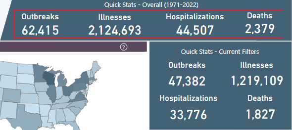

Image was obtained from: https://www.cdc.gov/ncezid/dfwed/beam-dashboard.html (NORS view dashboard)

In conclusion, NAs and blanks can be kept in the dataset.

## Create a new column called Date to combine year and month

```r
# Create a new column Date to combine year and month as Datetime datatype
df$Date <- lubridate::ymd(paste(df$Year, df$Month, "01", sep = "-"))
```

Check column data type:

```r
# Check data type of Date column
class(df$Date)
```

```
[1] "Date"
```

## Select all the rows which have *Norovirus* as substring

```r
# Filter rows contain Norovirus as substring
norovirus_df <- df %>%
  filter(str_detect(df$Etiology, "Norovirus"))
```

## Present statistics on *Norovirus* that you think would be of interest to your project’s sponsor

### Which primary mode has the highest number of outbreaks?

```r
# Group data by Primary_Mode column and count the number of occurences
norovirus_by_primary_mode <- norovirus_df %>%
  count(Primary_Mode)

norovirus_by_primary_mode
```

| Primary_Mode | n |
| --- | --- |
| Environmental contamination other than food/water | 61 |
| Food | 6861 |
| Indeterminate/unknown | 2041 |
| Person-to-person | 21214 |
| Water | 136 |

Result: *Person-to-person* is the main reason of *Norovirus* outbreaks, with 21214 cases.

### Where are the top 3 places that outbreaks occur most frequently when the primary mode is *Person-to-person*?

```r
top_3_norovirus_places <- norovirus_df %>%
  # Select Person-to-person as the primary mode and filter out NAs from Setting column
  filter(Primary_Mode == "Person-to-person", !is.na(Setting)) %>%
  # Group data by Setting column and count the number of occurences
  count(Setting) %>%
  filter(n > 0)

top_3_norovirus_places %>% arrange(desc(top_3_norovirus_places$n))
```

| Setting | n |
| --- | --- |
| Long-term care/nursing home/assisted living facility | 13557 |
| School/college/university | 2044 |
| Child daycare/preschool | 1077 |
| Hospital | 619 |
| Other | 455 |
| Restaurant | 269 |
| Other healthcare facility | 148 |
| Camp | 139 |
| Private home/residence | 112 |
| Event space | 99 |

[output cut: 10 more lines]

## Create graphs to visualize the statistics of *Norovirus*

### Which primary mode has the highest number of outbreaks?

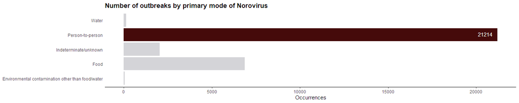

```r
# Create a horizontal bar chart
ggplot(
  norovirus_by_primary_mode,
  aes(x = n, y = Primary_Mode)
) +
  geom_bar(
    stat = "identity",
    aes(fill = ifelse(n == max(n), r_900, z_300))
  ) +
  geom_text(
    # Display text for only the bar with highest number of occurrences
    aes(label = ifelse(n == max(n), n, "")),
    color = "white",
    hjust = 1.35,
    vjust = 0.35
  ) +
  # Enable custom fill color
  scale_fill_identity() +
  labs(
    title = "Number of outbreaks by primary mode of Norovirus",
    x = "Occurrences"
  ) +
  # Adjust theme for a better look
  theme_classic() +
  theme(
    plot.title = element_text(face = "bold"),
    axis.title.x = element_text(),
    axis.title.y = element_blank(),
    axis.text.y = element_text(),
    axis.line.y = element_blank(),
    axis.ticks.y = element_blank()
  )
```

### Where are the top 3 places that outbreaks occur most frequently when the primary mode is *Person-to-person*?

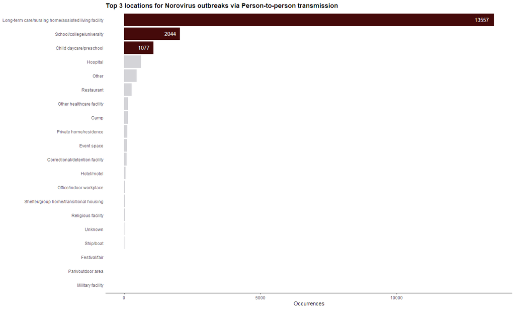

```r
is_top_3_places <- function(setting) {
  return(setting %in% c(
      "Child daycare/preschool",
      "School/college/university",
      "Long-term care/nursing home/assisted living facility"
    )
  )
}

ggplot(
  top_3_norovirus_places,
  # x-axis is the number of occurrences, y-axis is sorted by descending of n
  aes(x = n, y = reorder(Setting, n))
) +
  geom_bar(
    stat = "identity",
    aes(fill = ifelse(is_top_3_places(Setting), r_900, z_300))
  ) +
  geom_text( # size in pt
    aes(label = ifelse(is_top_3_places(Setting), n, "")),
    color = "white",
    hjust = 1.35,
    vjust = 0.35
  ) +
  scale_fill_identity() +
  labs(
    title = "Top 3 locations for Norovirus outbreaks via Person-to-person transmission",
    x = "Occurrences"
  ) +
  # Adjust theme for a better look
  theme_classic() +
  theme(
    plot.title = element_text(face = "bold"),
    axis.title.x = element_text(),
    axis.title.y = element_blank(),
    axis.text.y = element_text(),
    axis.line.y = element_blank(),
    axis.ticks.y = element_blank()
  )
```

## Select all the rows which have *Escherichia* as substring

```r
# Filter rows contain Escherichia as substring
escherichia_coli_df <- df %>%
  filter(str_detect(df$Etiology, "Escherichia"))
```

## Determine how to handle instances where multiple etiologies are listed

Instances with multiple etiologies can be split into multiple rows. However, this approach is only suitable for data visualization scenarios when only a few columns are selected to plot a graph. It cannot be applied to the entire dataset because some values, like the number of illnesses, hospitalizations, and deaths, cannot be split.

## Present statistics on *Escherichia coli* that you think would be of interest to your project’s sponsor

### Which primary mode has the highest number of outbreaks?

```r
# Group data by Primary_Mode column and count the number of occurences
escherichia_coli_by_primary_mode <- escherichia_coli_df %>%
  count(Primary_Mode)

escherichia_coli_by_primary_mode
```

| Primary_Mode | n |
| --- | --- |
| Animal contact | 82 |
| Environmental contamination other than food/water | 9 |
| Food | 784 |
| Indeterminate/unknown | 230 |
| Person-to-person | 248 |
| Water | 91 |

Result: *Food* is the main reason of *Escherichia coli* outbreaks, with 784 cases.

### Which food vehicle and IFSAC category is the most frequently associated with outbreaks when the primary mode is *Food*?

```r
food_vehicles_and_setting <- escherichia_coli_df %>%
  # Select Food as the primary mode and filter out NAs from Food Vehicle and Setting columns
  filter(Primary_Mode == "Food", !is.na(Food_Vehicle), !is.na(Setting)) %>%
  # Split multiple food vehicles into separate rows, with delimiter is semicolon ';'
  separate_longer_delim(Food_Vehicle, delim = ";") %>%
  # Group data by Setting column and count the number of occurences
  count(Food_Vehicle, Setting) %>%
  # Sort by descending of n
  arrange(desc(n))

food_vehicles_and_setting
```

| Food_Vehicle | Setting | n |
| --- | --- | --- |
| ground beef, hamburger | Private home/residence | 27 |
| ground beef | Private home/residence | 12 |
| ground beef, unspecified | Private home/residence | 11 |
| apple cider, unpasteurized | Other | 6 |
| ground beef, hamburger | Restaurant: Sit-down dining | 5 |
| ground beef, hamburger | Other | 4 |
| ground beef, unspecified | Other | 4 |
| ground beef, unspecified | Restaurant: Other;Private home/residence | 4 |
| lettuce, unspecified | Restaurant: Other | 4 |
| lettuce-based salads unspecified | Restaurant: Other | 4 |

[output cut: 386 more lines]

## Create graphs to visualize the statistics of *Escherichia coli*

### Which primary mode has the highest number of outbreaks?

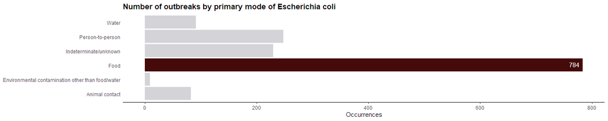

```r
# Create a horizontal bar chart
ggplot(
  escherichia_coli_by_primary_mode,
  aes(x = n, y = Primary_Mode)
) +
  geom_bar(
    stat = "identity",
    aes(fill = ifelse(n == max(n), r_900, z_300))
  ) +
  geom_text(
    # Display text for only the bar with highest number of occurrences
    aes(label = ifelse(n == max(n), n, "")),
    color = "white",
    hjust = 1.35,
    vjust = 0.35
  ) +
  # Enable custom fill color
  scale_fill_identity() +
  labs(
    title = "Number of outbreaks by primary mode of Escherichia coli",
    x = "Occurrences"
  ) +
  # Adjust theme for a better look
  theme_classic() +
  theme(
    plot.title = element_text(face = "bold"),
    axis.title.x = element_text(),
    axis.title.y = element_blank(),
    axis.text.y = element_text(),
    axis.line.y = element_blank(),
    axis.ticks.y = element_blank()
  )
```

### Which food vehicle and IFSAC category is the most frequently associated with outbreaks when the primary mode is *Food*?

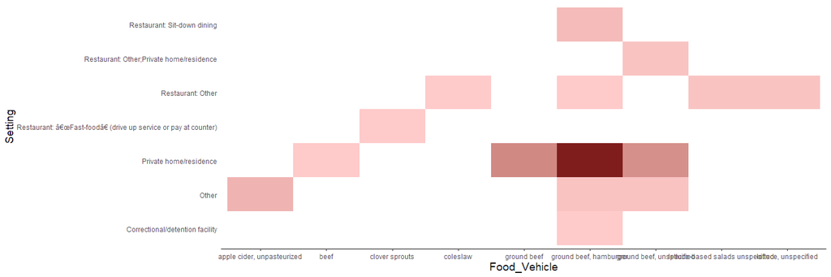

```r
ggplot(
  head(food_vehicles_and_setting, n=15),
  aes(
    x = Food_Vehicle,
    y = Setting,
    fill = n
  )
) +
  geom_tile() +
  scale_fill_gradient(low = "#fecaca", high = "#7f1d1d") +
  theme_classic() +
  theme(
    # Hide the legend
    legend.position = "none",
    panel.grid = element_blank(),
    plot.title = element_text(
      size = 16,
      face = "bold",
      margin = margin(b = 10)
    ),
    axis.title = element_text(size = 14),
    axis.line.y = element_blank(),
    axis.ticks.y = element_blank()
  )
```